# Mortalidade por tumores no Sistema Nervoso Central (SNC) em crianças e adolescentes no Brasil

Iago Vale e Júlia Gualberto

2022-10-19

## Introdução

O cérebro e a medula espinhal formam o Sistema Nervoso Central (SNC). Os tumores do SNC devem-se ao crescimento de células anormais nos tecidos dessas localizações. O câncer do SNC representa de 1,4 a 1,8% de todos os tumores malignos no mundo. Cerca de 88% dos tumores de SNC são no cérebro. Na maioria dos outros órgãos do corpo, é muito importante fazer a distinção entre tumores benignos e malignos. Os tumores benignos em outras regiões não invadem os tecidos vizinhos ou se disseminam para outros órgãos. Uma das principais razões do câncer ser perigoso é porque ele pode se disseminar por todo o corpo. Embora os tumores cerebrais raramente se espalhem para outros órgãos, a maioria pode se disseminar através do tecido cerebral. Mesmo os chamados tumores benignos podem, à medida que crescem, destruir e/ou comprimir o tecido normal do cérebro, causando danos que muitas vezes são incapacitantes e por vezes fatais. Por esta razão, os médicos costumam falar de tumores cerebrais em vez de câncer do cérebro. A principal preocupação com os tumores cerebrais é a facilidade com que podem se disseminar para a medula espinhal ou no próprio cérebro. Os tumores cerebrais e da medula espinhal são diferentes em adultos e crianças. Eles se formam em diferentes áreas, se desenvolvem a partir de diferentes tipos de células, e podem ter um prognóstico e tratamento também diferentes. Umas das diferenças epidemiológicas importantes se refere ao fato de que os tumores do sistema nervoso central são os tumores sólidos mais prevalentes na faixa etária pediátrica e ficam em segundo lugar geral em prevalência perdendo apenas para leucemia e linfomas. Existem muitos tipos de tumores cerebrais e o tratamento e prognóstico de cada um é diferente. A maioria dos tumores cerebrais em crianças se inicia na parte inferior do SNC, como cerebelo e tronco cerebral. Esses tumores podem provocar dores de cabeça, náuseas, vômitos, visão turva ou dupla, tontura e dificuldade para caminhar ou manipular objetos. Os tumores da medula espinhal são menos comuns do que os tumores cerebrais tanto em crianças como em adultos.

## Sobre os dados

Os dados foram coletados diretamente do DATASUS, uma plataforma do governo federal, que serve para subsidiar análises objetivas sobre diversos assuntos. Vão ser utilizados dados de óbitos por CID-10 (D43), no período de anos 2000 até 2020, visualizados também por faixa etária, menos de 1 ano, 1 à 4 anos, 5 à 9 anos, 10 à 14 anos e 15 à 19 anos.

## Análise Descritiva

Com o gráfico abaixo podemos visualizar a quantidade de casos de câncer no Sistema Nervoso Central em cada faixa etária. Nota-se que o número de casos em crianças com menos de 1 ano é bem inferior se comparado com outras faixas etárias.

#### **Gráfico 1 -** Número de Casos por Faixa Etária

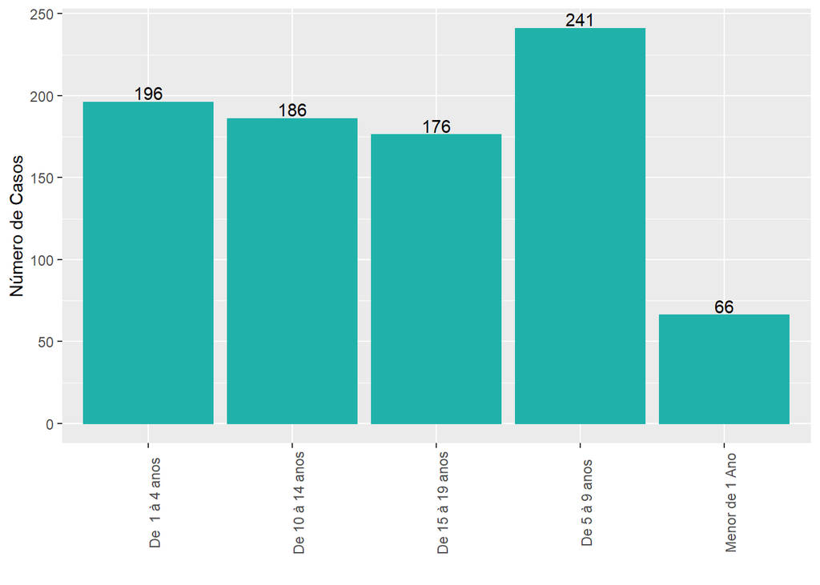

#### **Gráfico 2 -** Evoulução do Número de Casos ao Longo dos Anos por Faixa Etária

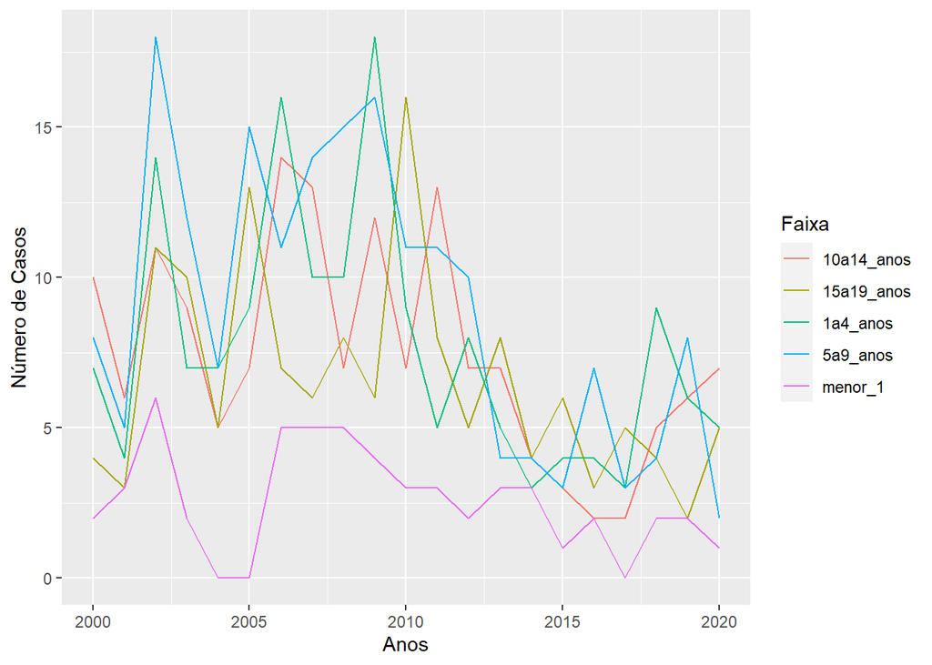

O gráfico acima nos permite observar que o comportamento para todas as faixas etárias, com exceção a de menor de 1 ano, é parecido é tem um decréscimo no número de casos a partir de 2010. O que fica ainda mais claro com o gráfico abaixo, onde podemos ver nitidamente essa “queda” no número de casos a partir de 2010 sem considerar as faixas etárias.

#### **Gráfico 3 -** Evoulução do Número de Casos ao Longo dos Anos

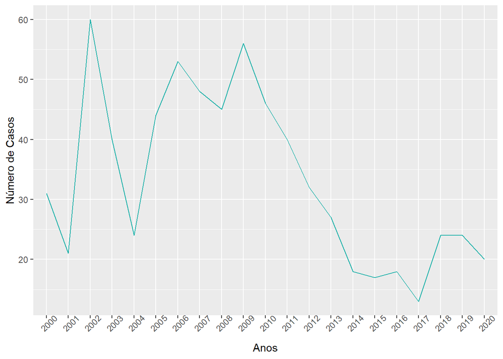

### Taxa de Óbitos por D43 em Relação aos Óbitos por Neoplasias em Geral

O cálculo da taxa de óbitos de D43 em relação aos óbitos por neoplasias em geral, foi obtido por:
$$\frac{\mathrm{número \ de \ óbitos \ por \
D43}}{\mathrm{número \ de \ óbitos\ por\ neoplasias \ em \
geral}}$$

#### **Tabela 1:**

| Anos | Óbitos por D43 | Óbitos por Neoplasias | Taxas |
| --- | --- | --- | --- |
| 2000 | 31 | 3074 | 1.0084580 |
| 2001 | 21 | 3017 | 0.6960557 |
| 2002 | 60 | 3160 | 1.8987342 |
| 2003 | 40 | 3121 | 1.2816405 |
| 2004 | 24 | 3093 | 0.7759457 |
| 2005 | 44 | 3143 | 1.3999364 |
| 2006 | 53 | 3198 | 1.6572858 |
| 2007 | 48 | 3160 | 1.5189873 |
| 2008 | 45 | 3049 | 1.4758937 |
| 2009 | 56 | 3166 | 1.7687934 |
| 2010 | 46 | 2965 | 1.5514334 |
| 2011 | 40 | 3022 | 1.3236267 |
| 2012 | 32 | 3174 | 1.0081916 |
| 2013 | 27 | 2982 | 0.9054326 |
| 2014 | 18 | 2879 | 0.6252171 |
| 2015 | 17 | 2920 | 0.5821918 |
| 2016 | 18 | 2874 | 0.6263048 |
| 2017 | 13 | 2637 | 0.4929845 |
| 2018 | 24 | 2680 | 0.8955224 |
| 2019 | 24 | 2668 | 0.8995502 |
| 2020 | 20 | 2399 | 0.8336807 |

Com o gráfico abaixo podemos visualizar de forma mais didática as informações expostas na tabela acima. Vale ressaltar que assim como acontece com o número de casos a taxa de óbitos por D43 tem uma diminuição significativa a partir de 2010.

#### **Gráfico 4** - Taxa de Óbitos por D43 em Relação aos Óbitos por Neoplasias em Geral

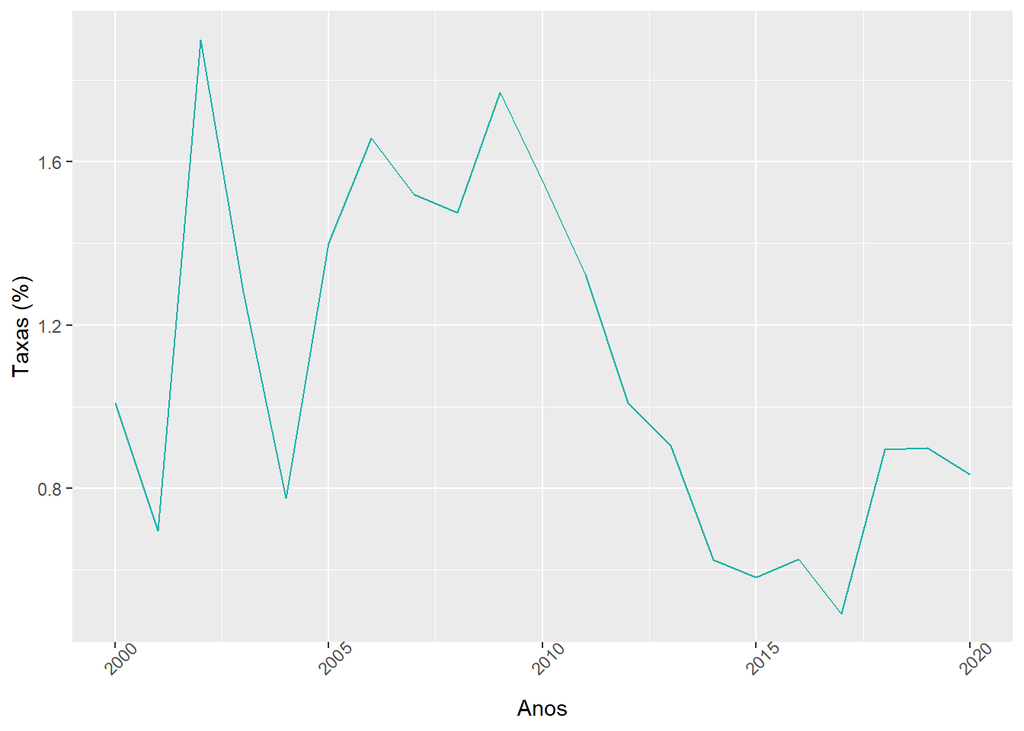

### Taxa de Óbitos por D43 em Relação ao Total Populacional

O cálculo da taxa de óbitos de D43 em relação a população geral, foi obtido por:
$$\frac{\mathrm{número \ de \
óbitos \ por \ D43}}{\mathrm{total \ populacional}} \cdot
100.000$$

#### **Tabela 2:**

| Anos | Número de Óbitos por D43 | População | Taxa |
| --- | --- | --- | --- |
| 2000 | 31 | 70582044 | 0.0439205 |
| 2001 | 21 | 70355956 | 0.0298482 |
| 2002 | 60 | 69943897 | 0.0857830 |
| 2003 | 40 | 69439859 | 0.0576038 |
| 2004 | 24 | 68887561 | 0.0348394 |
| 2005 | 44 | 68322694 | 0.0644003 |
| 2006 | 53 | 67736042 | 0.0782449 |
| 2007 | 48 | 67107446 | 0.0715271 |
| 2008 | 45 | 66495752 | 0.0676735 |
| 2009 | 56 | 65908414 | 0.0849664 |
| 2010 | 46 | 65323903 | 0.0704183 |
| 2011 | 40 | 64737332 | 0.0617882 |
| 2012 | 32 | 64191812 | 0.0498506 |
| 2013 | 27 | 63652735 | 0.0424177 |
| 2014 | 18 | 63140136 | 0.0285080 |
| 2015 | 17 | 62660774 | 0.0271302 |
| 2016 | 18 | 62097280 | 0.0289868 |
| 2017 | 13 | 61485414 | 0.0211432 |
| 2018 | 24 | 60931765 | 0.0393883 |
| 2019 | 24 | 60414151 | 0.0397258 |
| 2020 | 20 | 59961535 | 0.0333547 |

#### **Gráfico 5** - Taxa de Óbitos por D43 em Relação ao Total Populacional

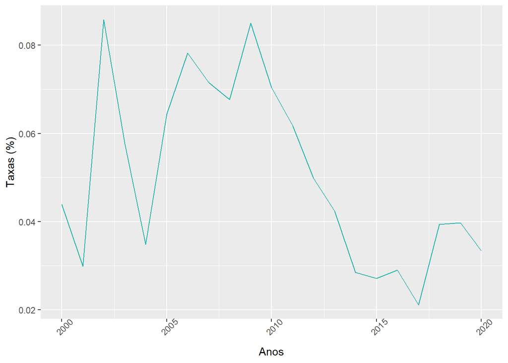

#### **Gráfico 6 -** Mapa de Taxas de Mortalidade por Região e Faixa Etária

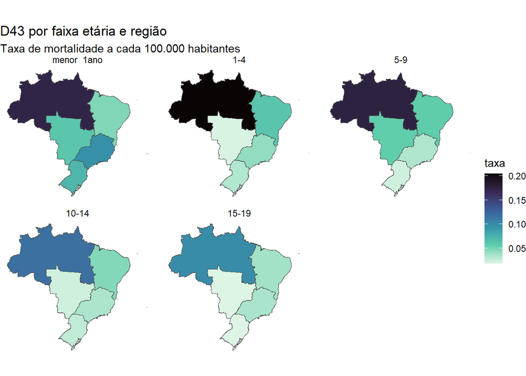

#### **Tabela 3:**

| regiao | faixa_et | n_total | taxa |
| --- | --- | --- | --- |
| centro-oeste | menor_1ano | 3 | 0.0605 |
| centro-oeste | 1-4 | 4 | 0.0202 |
| centro-oeste | 5-9 | 14 | 0.0558 |
| centro-oeste | 10-14 | 6 | 0.0233 |
| centro-oeste | 15-19 | 5 | 0.0187 |
| nordeste | menor_1ano | 9 | 0.0476 |
| nordeste | 1-4 | 48 | 0.0614 |
| nordeste | 5-9 | 58 | 0.0567 |
| nordeste | 10-14 | 50 | 0.0465 |
| nordeste | 15-19 | 41 | 0.0368 |
| norte | menor_1ano | 12 | 0.1733 |
| norte | 1-4 | 58 | 0.2045 |
| norte | 5-9 | 63 | 0.1761 |
| norte | 10-14 | 42 | 0.1174 |
| norte | 15-19 | 35 | 0.1000 |
| sudeste | menor_1ano | 24 | 0.0967 |
| sudeste | 1-4 | 42 | 0.0422 |
| sudeste | 5-9 | 43 | 0.0334 |
| sudeste | 10-14 | 46 | 0.0344 |
| sudeste | 15-19 | 49 | 0.0345 |
| sul | menor_1ano | 6 | 0.0713 |
| sul | 1-4 | 11 | 0.0327 |
| sul | 5-9 | 10 | 0.0227 |
| sul | 10-14 | 13 | 0.0279 |
| sul | 15-19 | 9 | 0.0182 |

## Análise Temporal

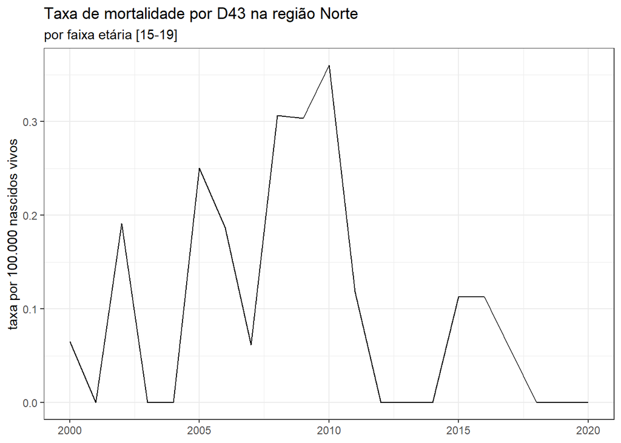

Com o gráfico acima podemos observar um comportamento cíclico no período de 2000 até 2010, além disso é possível visualizar uma diminuição das taxas a partir dessa data.

Sabe-se que a função de autocorrelação (ACF) e a função de autocorrelação parcial (PACF, também chamada de ACF parcial) são funções muito importantes na análise de uma série temporal. Um ACF mede e plota a correlação média entre pontos de dados em séries temporais e valores anteriores da série medidos para diferentes comprimentos de defasagem (lag). Já ao falar sobre o PACF podemos dizer que é semelhante a um ACF, com exceção que cada correlação parcial controla qualquer correlação entre observações de um comprimento de defasagem mais curto.

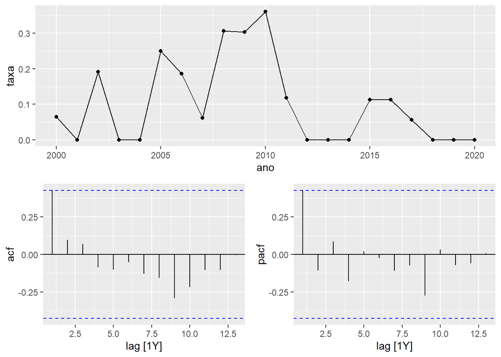

Com o gráfico acima é possível perceber que existem *lags* significantes que estão acima ou na linha tracejada em azul, que representam o intervalo de confiança. Além disso, o gráfico da indícios de um modelo ARMA(1,1). Com isso iniciaremos a construção do modelo.

### **Modelo ARMA(1,1)**

Para a construção do modelo é necessário realizar alguns testes, como por exemplo, o de estacionariedade. Para isso foi utilizado o teste da raíz unitária de *Dickey-Fuller*. Assumindo a hipótese nula de que a série não é estacionária, com os resultados abaixo aceitamos a hipótese nula, uma vez que, o p-valor é maior que 0,05. Ou seja, a série não é estacionária.

```
##
## ###############################################
## # Augmented Dickey-Fuller Test Unit Root Test #
## ###############################################
##
## Test regression none
##
##
## Call:
## lm(formula = z.diff ~ z.lag.1 - 1 + z.diff.lag)
##
## Residuals:
##      Min       1Q   Median       3Q      Max
## -0.13382 -0.03445  0.00000  0.10906  0.25217
##
## Coefficients:
##            Estimate Std. Error t value Pr(>|t|)
## z.lag.1    -0.28656    0.19076  -1.502    0.151
## z.diff.lag -0.08217    0.23976  -0.343    0.736
##
## Residual standard error: 0.1236 on 17 degrees of freedom
## Multiple R-squared:  0.1619, Adjusted R-squared:  0.0633
## F-statistic: 1.642 on 2 and 17 DF,  p-value: 0.2229
##
##
## Value of test-statistic is: -1.5022
##
## Critical values for test statistics:
##       1pct  5pct 10pct
## tau1 -2.66 -1.95  -1.6
```

Uma vez que a série não é estacionária, se fez necessário fazer algumas manipulações afim de obter um melhor modelo preditivo. Dessa forma, foi realizada a diferenciação da série, que é usada para remover os sinais de tendências e reduzir a variância, ela simplesmente é a diferença do valor do período T com o valor do período anterior T-1. Após realizar a diferenciação foi feito o mesmo teste da raíz unitária, e como podemos observar se rejeita a hipótese nula, ou seja, a série é estacionária.

```
##
## ###############################################
## # Augmented Dickey-Fuller Test Unit Root Test #
## ###############################################
##
## Test regression none
##
##
## Call:
## lm(formula = z.diff ~ z.lag.1 - 1 + z.diff.lag)
##
## Residuals:
##      Min       1Q   Median       3Q      Max
## -0.22804 -0.06915 -0.01927  0.02688  0.19267
##
## Coefficients:
##            Estimate Std. Error t value Pr(>|t|)
## z.lag.1     -1.5703     0.3474  -4.520 0.000348 ***
## z.diff.lag   0.3130     0.2212   1.415 0.176146
## ---
## Signif. codes:  0 '***' 0.001 '**' 0.01 '*' 0.05 '.' 0.1 ' ' 1
##
## Residual standard error: 0.1208 on 16 degrees of freedom
## Multiple R-squared:  0.666,  Adjusted R-squared:  0.6242
## F-statistic: 15.95 on 2 and 16 DF,  p-value: 0.000155
##
##
## Value of test-statistic is: -4.5205
##
## Critical values for test statistics:
##       1pct  5pct 10pct
## tau1 -2.66 -1.95  -1.6
```

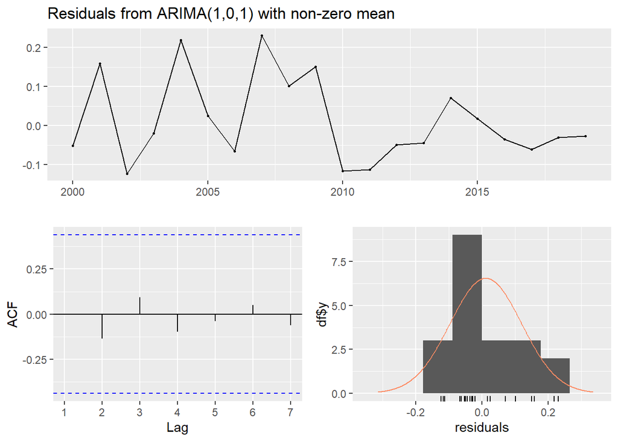

```
##
##  Ljung-Box test
##
## data:  Residuals from ARIMA(1,0,1) with non-zero mean
## Q* = 0.98357, df = 3, p-value = 0.8052
##
## Model df: 2.   Total lags used: 5
```

Outra hipótese assumida na derivação da função de verossimilhança dos modelos AR(p), MA(q) e ARMA(p,q) é que a série temporal dos retornos segue uma distribuição Normal o que, por conseguinte, define que os resíduos também têm a mesma distribuição de probabilidade. Uma alternativa para isso é o teste Jarque Bera.

```
##
##  Jarque Bera Test
##
## data:  model$residuals
## X-squared = 2.2057, df = 2, p-value = 0.3319
```

A hipótese nula do teste é que os dados são normalmente distribuídos contra a hipótese alternativa que os dados não são normalmente distribuídos. Sabemos que o p-valor é o nível de significância mínimo para se rejeitar a hipótese nula. Assim, queremos um p-valor alto (>0,05) o que não nos permite rejeitá-la. Observe que é exatamente isso que o resultado do nosso teste mostra e, assim, não podemos rejeitar a hipótese nula de normalidade nos dados.

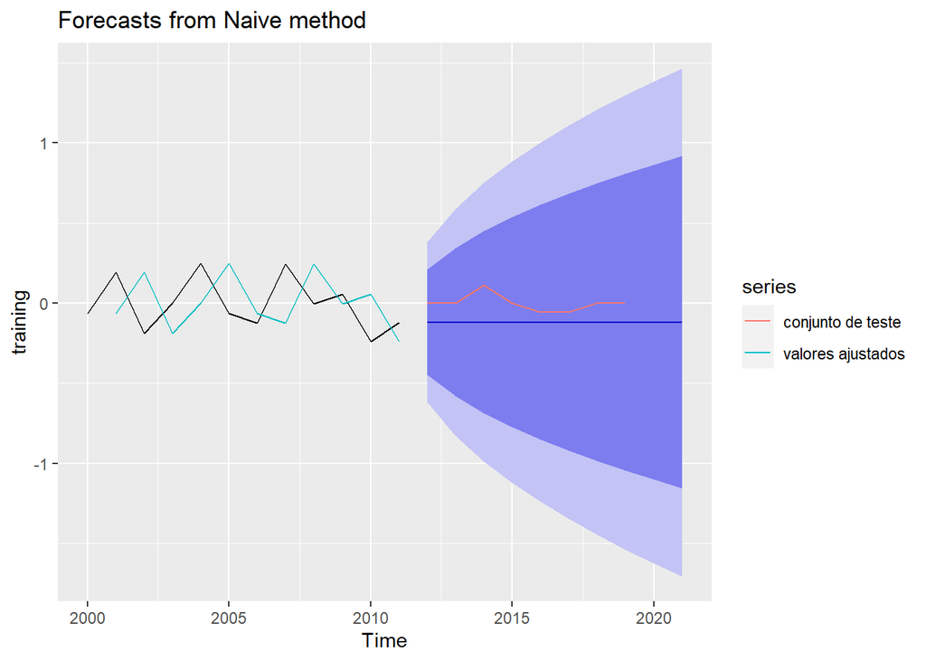

```
##                        ME      RMSE       MAE MPE MAPE      MASE       ACF1
## Training set -0.004844352 0.2556038 0.2320839 Inf  Inf 1.0000000 -0.5121487
## Test set      0.118518167 0.1282251 0.1185182 Inf  Inf 0.5106695  0.1654272
##              Theil's U
## Training set        NA
## Test set           NaN
```